# Ford GoBike Data exploration

## by Shreyas Raghavan

### Introduction

Ford GoBike has increasingly gained popularity as one of the best bike sharing facilitator present in the United States. In this report we would focus on the customer behaviour which would help us understand our target customer. We would also be seeing the duration of trips and other essential targets such as the station's to understand more.

### Preliminary Wrangling

> Our analysis uses the data pertaining to trips on Ford GoBike for the month of August 2018. Our major aim is to understand the following.
> 1. When are most trips taken in terms of time of day of the week
> 2. Does the above depend on if a user is a subscriber or customer?
> 3. Who should be our target customers ? In terms of advertising , who are our target audience ?

```python
# import all packages and set plots to be embedded inline
import numpy as np
import pandas as pd
import matplotlib.pyplot as plt
import seaborn as sb
#from mpl_toolkits.basemap import Basemap
%matplotlib inline
```

```python
df = pd.read_csv("C:Desktop/201808-fordgobike-tripdata.csv")
```

Before , We move any further we must take a look at the size of the data.

```python
df.shape
```

```
(192162, 16)
```

The only wrangling we are going to do is to figure out the age of the customers present. This way , we'd be able to understand much better.

```python
df['member_age'] = 2018 - df['member_birth_year']
```

### What is the structure of your dataset?

Our data contains **192162 records for 16 columns**. We can have a glimpse of the dataset below ,

```python
df.head()
```

|  | duration_sec | start_time | end_time | start_station_id | start_station_name | start_station_latitude | start_station_longitude | end_station_id | end_station_name | end_station_latitude | end_station_longitude | bike_id | user_type | member_birth_year | member_gender | bike_share_for_all_trip | weekday_start | weekday_end | member_age |
| --- | --- | --- | --- | --- | --- | --- | --- | --- | --- | --- | --- | --- | --- | --- | --- | --- | --- | --- | --- |
| 31 | 286 | 2018-08-31 23:53:06.728 | 2018-08-31 23:57:52.931 | 109.0 | 17th St at Valencia St | 37.763316 | -122.421904 | 356.0 | Valencia St at Clinton Park | 37.769188 | -122.422285 | 1190 | Subscriber | 1985.0 | Female | No | Friday | Friday | 33.0 |
| 32 | 269 | 2018-08-31 23:49:04.040 | 2018-08-31 23:53:33.355 | 243.0 | Bancroft Way at College Ave | 37.869360 | -122.254337 | 266.0 | Parker St at Fulton St | 37.862464 | -122.264791 | 1026 | Subscriber | 1997.0 | Male | No | Friday | Friday | 21.0 |
| 33 | 3161 | 2018-08-31 22:59:04.364 | 2018-08-31 23:51:45.935 | 122.0 | 19th St at Mission St | 37.760299 | -122.418892 | 356.0 | Valencia St at Clinton Park | 37.769188 | -122.422285 | 4447 | Subscriber | 1963.0 | Male | Yes | Friday | Friday | 55.0 |
| 34 | 551 | 2018-08-31 23:42:29.445 | 2018-08-31 23:51:41.292 | 88.0 | 11th St at Bryant St | 37.770030 | -122.411726 | 41.0 | Golden Gate Ave at Polk St | 37.781270 | -122.418740 | 610 | Subscriber | 1983.0 | Male | No | Friday | Friday | 35.0 |
| 35 | 652 | 2018-08-31 23:38:58.559 | 2018-08-31 23:49:50.947 | 13.0 | Commercial St at Montgomery St | 37.794231 | -122.402923 | 62.0 | Victoria Manalo Draves Park | 37.777791 | -122.406432 | 3227 | Subscriber | 1994.0 | Male | No | Friday | Friday | 24.0 |

### What is/are the main feature(s) of interest in your dataset?

Our basic aim is to find when has the most number of trips been taken , whether an average time for subscriber differs from customer , if so then what would this difference mean to us ? Hence , Duration and user_type seems to be a good start but thinking from a sales perspective we must also evaluate which station is more profitable for us. Also , from other sales persepctive we may also want to see about the type of customer on the basis of age/gender to target more customers use our service.

### What features in the dataset do you think will help support your investigation into your feature(s) of interest?

As previously mentioned , Our main feature would be

1. Station start
2. Duration
3. Station end
4. User_type

From sales perspective ,

1. Member_gender
2. Member_birth_year

## Univariate Exploration

Before we further proceed into the Univariate analysis , Let us look at the statistical summary of the data and also our data depth

```python
df.describe(include = 'all')
```

|  | duration_sec | start_time | end_time | start_station_id | start_station_name | start_station_latitude | start_station_longitude | end_station_id | end_station_name | end_station_latitude | end_station_longitude | bike_id | user_type | member_birth_year | member_gender | bike_share_for_all_trip | weekday_start | weekday_end | member_age |
| --- | --- | --- | --- | --- | --- | --- | --- | --- | --- | --- | --- | --- | --- | --- | --- | --- | --- | --- | --- |
| count | 192131.000000 | 192131 | 192131 | 189219.000000 | 189219 | 192131.000000 | 192131.000000 | 189219.000000 | 189219 | 192131.000000 | 192131.000000 | 192131.000000 | 192131 | 181218.000000 | 181258 | 192131 | 192131 | 192131 | 181218.000000 |
| unique | NaN | 192110 | 192117 | NaN | 306 | NaN | NaN | NaN | 306 | NaN | NaN | NaN | 2 | NaN | 3 | 2 | 7 | 7 | NaN |
| top | NaN | 2018-08-08 08:40:52.997000 | 2018-08-08 14:37:52.786000 | NaN | San Francisco Caltrain Station 2 (Townsend St... | NaN | NaN | NaN | San Francisco Caltrain Station 2 (Townsend St... | NaN | NaN | NaN | Subscriber | NaN | Male | No | Wednesday | Wednesday | NaN |
| freq | NaN | 2 | 2 | NaN | 3936 | NaN | NaN | NaN | 5422 | NaN | NaN | NaN | 161426 | NaN | 131042 | 176747 | 36674 | 36638 | NaN |
| first | NaN | 2018-08-01 00:00:01.659000 | 2018-08-01 00:07:21.643000 | NaN | NaN | NaN | NaN | NaN | NaN | NaN | NaN | NaN | NaN | NaN | NaN | NaN | NaN | NaN | NaN |
| last | NaN | 2018-08-31 23:53:06.728000 | 2018-08-31 23:57:52.931000 | NaN | NaN | NaN | NaN | NaN | NaN | NaN | NaN | NaN | NaN | NaN | NaN | NaN | NaN | NaN | NaN |
| mean | 868.140368 | NaN | NaN | 123.507639 | NaN | 37.766251 | -122.343524 | 122.601192 | NaN | 37.766360 | -122.343109 | 2181.383821 | NaN | 1983.622146 | NaN | NaN | NaN | NaN | 34.377854 |
| std | 2377.684846 | NaN | NaN | 102.125024 | NaN | 0.112900 | 0.239341 | 102.802429 | NaN | 0.112823 | 0.239097 | 1204.448148 | NaN | 10.313588 | NaN | NaN | NaN | NaN | 10.313588 |
| min | 61.000000 | NaN | NaN | 3.000000 | NaN | 37.312854 | -122.473658 | 3.000000 | NaN | 37.312854 | -122.473658 | 11.000000 | NaN | 1888.000000 | NaN | NaN | NaN | NaN | 18.000000 |
| 25% | 355.000000 | NaN | NaN | 36.000000 | NaN | 37.770407 | -122.409449 | 30.000000 | NaN | 37.771058 | -122.408445 | 1176.000000 | NaN | 1978.000000 | NaN | NaN | NaN | NaN | 27.000000 |
| 50% | 564.000000 | NaN | NaN | 91.000000 | NaN | 37.781074 | -122.395526 | 90.000000 | NaN | 37.781270 | -122.395526 | 2230.000000 | NaN | 1986.000000 | NaN | NaN | NaN | NaN | 32.000000 |
| 75% | 887.000000 | NaN | NaN | 195.000000 | NaN | 37.797673 | -122.274894 | 195.000000 | NaN | 37.798014 | -122.278175 | 3169.000000 | NaN | 1991.000000 | NaN | NaN | NaN | NaN | 40.000000 |
| max | 85967.000000 | NaN | NaN | 367.000000 | NaN | 45.510000 | -73.570000 | 367.000000 | NaN | 45.510000 | -73.570000 | 4466.000000 | NaN | 2000.000000 | NaN | NaN | NaN | NaN | 130.000000 |

As we can see above , There are few interesting things which can be seen.

Before further moving on , We must evaluate the coverage of our data. This would enable us to understand how healthy our data is.

```python
pd.DataFrame(((df.count()-df.isnull().sum())/df.count())*100 , columns=['Coverage'])
```

|  | Coverage |
| --- | --- |
| duration_sec | 100.000000 |
| start_time | 100.000000 |
| end_time | 100.000000 |
| start_station_id | 98.461042 |
| start_station_name | 98.461042 |
| start_station_latitude | 100.000000 |
| start_station_longitude | 100.000000 |
| end_station_id | 98.461042 |
| end_station_name | 98.461042 |
| end_station_latitude | 100.000000 |
| end_station_longitude | 100.000000 |
| bike_id | 100.000000 |
| user_type | 100.000000 |
| member_birth_year | 93.977971 |
| member_gender | 94.001368 |
| bike_share_for_all_trip | 100.000000 |
| weekday_start | 100.000000 |
| weekday_end | 100.000000 |
| member_age | 93.977971 |

As we can see , Our data is healthy and good to go!

Let's take a look at it graphically , for a better understanding.

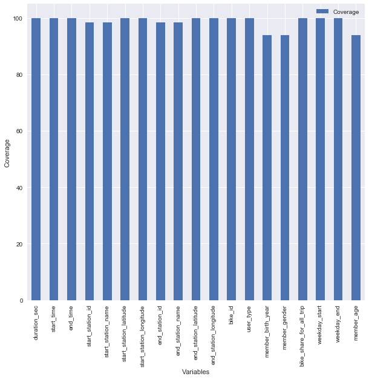

```python
ax = pd.DataFrame(((df.count()-df.isnull().sum())/df.count())*100 , columns=['Coverage']).plot(kind = 'bar' , figsize = (10,9))
ax.set(xlabel = 'Variables' , ylabel = 'Coverage')
plt.show()
```

As we can see from the above plot , Our variables are pretty good. This can also help us during modelling and during the feature selections (If we proceed further with it)

##### Duration in Seconds

Duration of the trip can be a key element. This would help us identify users and would also help us judge the time they take for the travel.

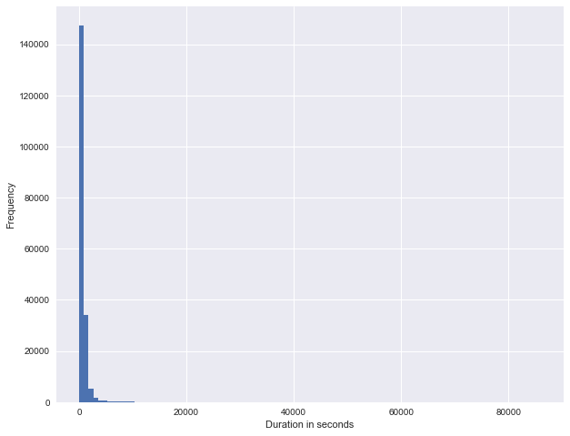

```python
df['duration_sec'].plot.hist(bins = 100 , figsize = (10 , 8)).set(xlabel = 'Duration in seconds')
plt.show()
```

```python
df['duration_sec'].describe().to_frame()
```

|  | duration_sec |
| --- | --- |
| count | 192162.000000 |
| mean | 871.052700 |
| std | 2413.884799 |
| min | 61.000000 |
| 25% | 355.000000 |
| 50% | 564.000000 |
| 75% | 887.000000 |
| max | 85967.000000 |

From the above plot , We can see that the users have taken more trips below 10000 seconds. Roughly , We can also infer that there are outliers to the pertaining data. We did note the very same on the description above too! Let's take use of our boxplots

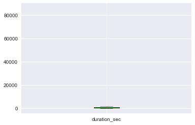

```python
color = dict(boxes='DarkGreen', whiskers='DarkOrange',medians='DarkBlue', caps='Gray')
df['duration_sec'].plot.box(color = color , sym = 'r+')
plt.show()
```

From the above plot , we can see that the concentration of rides are towards the lower end. I still firmly believe that the presence of outlier is hampering our cause. We can fix it by either limiting the y ticks or by using logarthimic transformation to our data

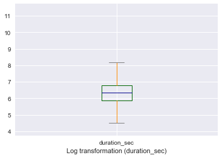

```python
color = dict(boxes='DarkGreen', whiskers='DarkOrange',medians='DarkBlue', caps='Gray')
np.log(df['duration_sec']).plot.box(color = color , sym = 'r+').set(xlabel = 'Log transformation (duration_sec)')
plt.show()
```

We used log transformation above and can see a good plot for the duration. Though this is a very good technique for handling outliers but , we must also figure out how many variables are particularly present above 10,000 , 20,000 , 30,000 and so on. For this , We can see the below text

```python
print("Length of duration below 5000 :-  " +
      str(df.query('duration_sec < 5000').shape[0]))
print("Length of duration above 10000 and below 200000 :-  " +
      str(df.query('duration_sec > 10000 and duration_sec < 20000').shape[0]))
print("Length of duration above 20000 and below 300000 :-  " +
      str(df.query('duration_sec > 20000 and duration_sec < 30000').shape[0]))
print("Length of duration above 30000 and below 400000 :-  " +
      str(df.query('duration_sec > 30000 and duration_sec < 40000').shape[0]))
print("Length of duration above 40000 and below 500000 :-  " +
      str(df.query('duration_sec > 40000 and duration_sec < 50000').shape[0]))
print("Length of duration above 50000  :-  " +
      str(df.query('duration_sec > 50000').shape[0]))

print('total sample length :- ' + str(df.shape[0]))
```

```
Length of duration below 5000 :-  190038
Length of duration above 10000 and below 200000 :-  560
Length of duration above 20000 and below 300000 :-  142
Length of duration above 30000 and below 400000 :-  60
Length of duration above 40000 and below 500000 :-  59
Length of duration above 50000  :-  154
total sample length :- 192162
```

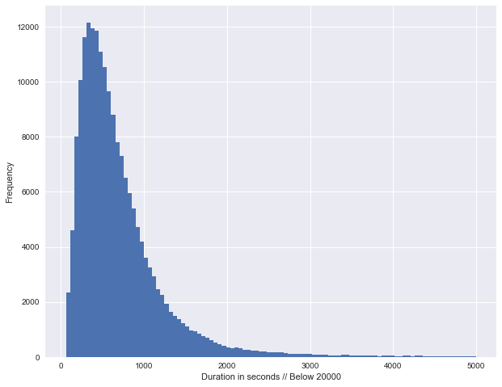

```python
df.query('duration_sec < 5000')['duration_sec'].plot.hist(bins = 100 ,
                                                          figsize = (10 , 8)).set(xlabel = 'Duration in seconds // Below 20000')
plt.show()
```

```python
df.query('duration_sec < 5000')['duration_sec'].describe().to_frame()
```

|  | duration_sec |
| --- | --- |
| count | 190038.000000 |
| mean | 702.822620 |
| std | 555.655526 |
| min | 61.000000 |
| 25% | 352.000000 |
| 50% | 559.000000 |
| 75% | 872.000000 |
| max | 4999.000000 |

As we can see that the distribution is not normal. The plot is right skewed and shows postivie skewness. Following are the observations from the above variable:

1. There are heavy outliers in our data. 1.1% of our records are for duration more than 5000 seconds.
2. We used log transformation to show normality in the boxplot above.
3. After plotting duration < 5000, we observed right skewness.

**This got me curious about the timing of the rides.**

##### Start_time and end_time

Before we go ahead, we must ensure that start time and end time are converted to datetime. This would help us get to the insights much more easily. After the sanity check is completed, we can go ahead with our plots and try to analyse the dates and time(hour) where the rides have been taken.

```python
df['start_time'] = pd.to_datetime(df['start_time'])
df['end_time'] = pd.to_datetime(df['end_time'])
df[['start_time','end_time']].dtypes
```

```
start_time    datetime64[ns]
end_time      datetime64[ns]
dtype: object
```

Let's look at one more sanity check for our data and figure out if the following data is for august or not. We must ensure that the month of august is selected for a uniform analysis.

```python
print(df['start_time'].dt.month.value_counts())
print(df['end_time'].dt.month.value_counts())
```

```
8    192162
Name: start_time, dtype: int64
8    192131
9        31
Name: end_time, dtype: int64
```

As we can see that september is included on 31 of our records. We are going to drop it as we just want to check for the month of August

```python
df = df[df['end_time'].dt.month == 8]
```

```python
df.shape
```

```
(192131, 16)
```

After the removal , We can see that 31 records have been removed. We may now proceed with our analysis

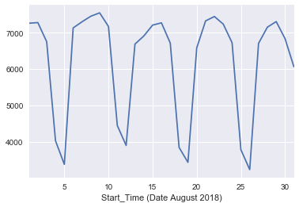

```python
a = df.start_time.dt.day.value_counts().sort_index().plot(kind = 'line').set(xlabel = 'Start_Time (Date August 2018)')
```

There seems to be a trend in terms of the ride taken. Looks like the trips tends to be higher on a particular time of the week than the other days.

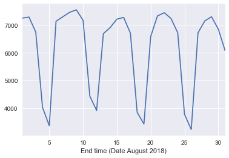

```python
b = df.end_time.dt.day.value_counts().sort_index().plot(kind = 'line').set(xlabel = 'End time (Date August 2018)')
```

No Surprise here. The plot yields similar to the above and there seems to be a particular weekwise trend. Hence , I am going to explore which time of the week has there been more rides

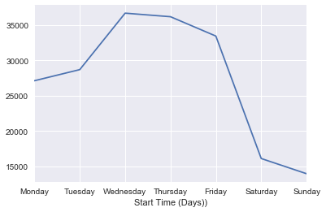

```python
## A list of days in the order that you need them:
dayofweek = {0:'Monday', 1:'Tuesday', 2:'Wednesday', 3:'Thursday', 4:'Friday', 5:'Saturday', 6:'Sunday'}
days = ['Monday','Tuesday','Wednesday','Thursday','Friday','Saturday', 'Sunday']

## Name the series to be plotted (allows you to access the index later):
day_counts = df.start_time.dt.dayofweek.map(dayofweek).value_counts()

## Re order the series index:
day_counts = day_counts.reindex(index = days)

## Plot the series:
a = day_counts.plot(kind = 'line')

# use index as tick labels
a.set_xticks(range(len(day_counts.index)))
a.set_xticklabels(day_counts.index)
a.set_xlabel('Start Time (Days))')
plt.show()
```

As expected , There seems to be spike in the ride during the mid week than in the other days. Also , The amount of rides decrease in the weekend. We can pretty well say that most of the office - goers love renting a bike from GoBike

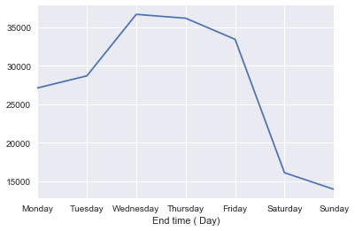

```python
## Name the series to be plotted (allows you to access the index later):
day_counts = df.start_time.dt.dayofweek.map(dayofweek).value_counts()
day_counts = day_counts.reindex(index = days)
## Plot the series:
a = day_counts.plot(kind = 'line')

# use index as tick labels
a.set_xticks(range(len(day_counts.index)))
a.set_xticklabels(day_counts.index)
a.set_xlabel('End time ( Day)')
plt.show()
```

Once again , As expected the plot seems to be the same.

```python
df['weekday_start'] = df.start_time.dt.dayofweek.map(dayofweek)
df['weekday_end'] = df.end_time.dt.dayofweek.map(dayofweek)
```

As we can see that the maximum number of rides are taken on Wednesday. Unsurprisingly Sunday seems to be a bit dull for Gobikes

We can very well infer the following :

1. There seems to be a trend in the ride share.
2. This enabled us to look closely towards the day of week which showed a increase in rentals on the mid week as compared to the weekend.

This brings us to the next section , **Which stations had the highest rental ?**

###### start_station_name and end station name

Let's take a look at the exploration of the stations through which the journey has begun for most of them! We would take a look at the top 20 bases.

```python
len(df['start_station_name'].value_counts())
```

```
306
```

Out of our 306 stations. We would just want to explore the 20 bases and they are plotted below

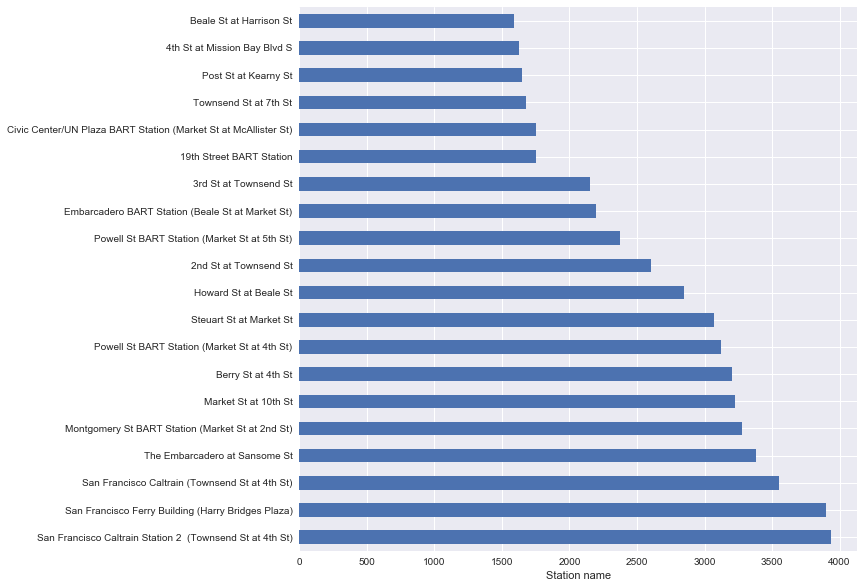

```python
df['start_station_name'].value_counts().sort_values(ascending = False)[:20].plot(kind = 'barh' ,
                                                                                 figsize = (10,10)).set(xlabel = 'Station name')
plt.show()
```

Let's take a look at the exploration of the stations through which the journey has ended for most of them! We would take a look at the top 20 bases.

```python
len(df['end_station_name'].value_counts())
```

```
306
```

Out of our 306 stations. We would just want to explore the 20 bases and they are plotted below

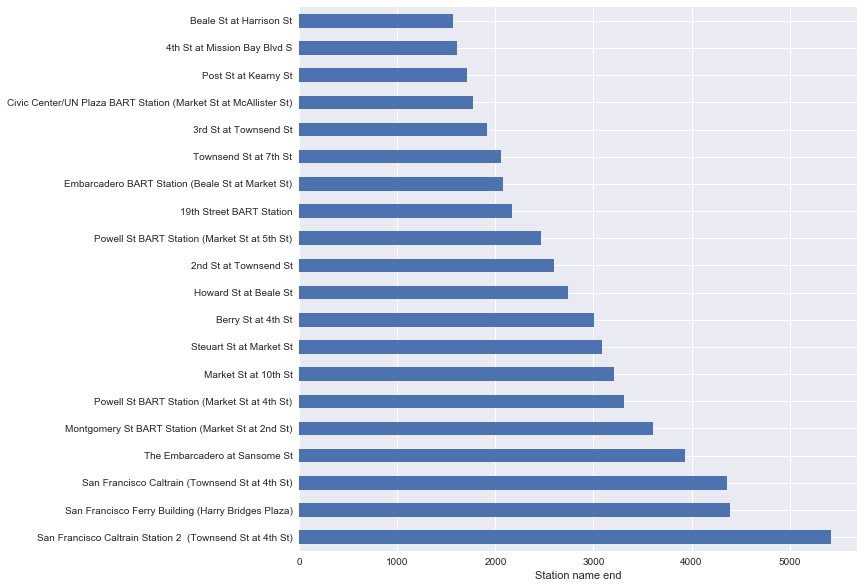

```python
df['end_station_name'].value_counts().sort_values(ascending = False)[:20].plot(kind = 'barh'
                                                                               , figsize = (10,10)).set(xlabel = 'Station name end')
plt.show()
```

**Before we move to the next plot , We have ignored the following variables (Start_station_id , end_station_latitude , end_station_longitude , start_station_latitude , start_station_longitude , end_station_id) Since they point towards the station name. We may look at the coordinates in the Bivariate section**

This brings us to our next section , **Who are our users ?**

##### Know your user

About 160k rides were from users who are Subscribers. So we can very well infer that we've a lot of recurring customers We can also look at the Gender and year of birth

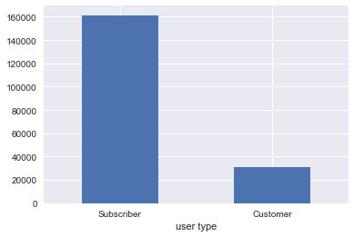

```python
(df.user_type.value_counts().plot(kind = 'bar' , rot = 0).set(xlabel = 'user type'))
plt.show()
```

**Who are our users ? What is their gender ? Is there any trend which is observed ?**

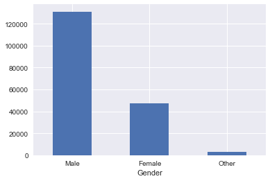

```python
(df.member_gender.value_counts().plot(kind = 'bar',rot = 0).set(xlabel = 'Gender'))
plt.show()
```

Most of our users are Male. The reasons ? Unknown

**What about their age and when did they come to existance in our beautiful planet ?**

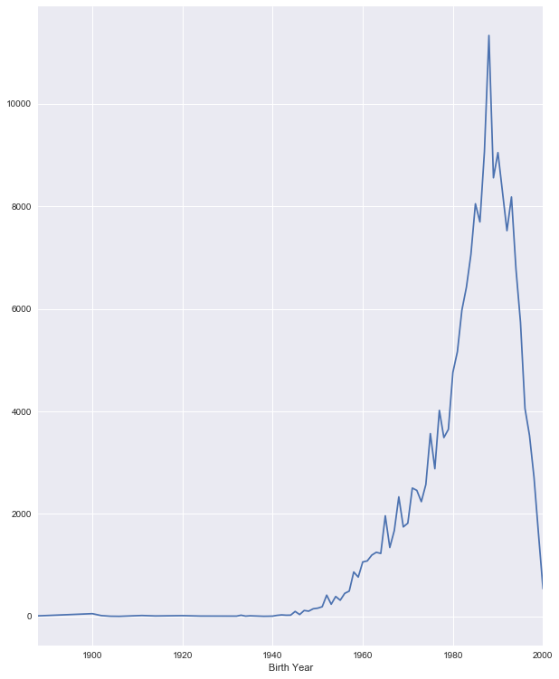

```python
(df.member_birth_year.value_counts().sort_index().plot(kind = 'line' , figsize = (10,13)).set(xlabel = 'Birth Year'))
plt.show()
```

Most of our users belong to the late 80's and 90's generation. Which can now be seen below in terms of age

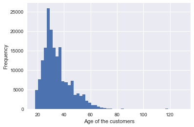

```python
df['member_age'].plot(kind = 'hist' , bins = 50).set(xlabel = 'Age of the customers')
plt.show()
```

The following brings us to our next question **Does everyone share their rides?**

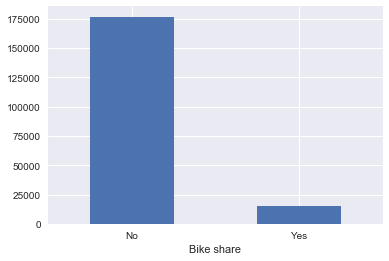

```python
df['bike_share_for_all_trip'].value_counts().plot(kind = 'bar' , rot = 0).set(xlabel = 'Bike share')
plt.show()
```

Answer ? No!

The following were observed :

1. Most of our users were Subscribers (Hence recurring rides)
2. From the data available to us , We found that we have a lot of Male users
3. Age is just a number , However we say that people in their late 20s and 30s tend to use our services a lot
4. Well , No they dont share the ride

### Discuss the distribution(s) of your variable(s) of interest. Were there any unusual points? Did you need to perform any transformations?

> We could notice that many of our variables are skewed. We had the duration time which had a lot of unusual points. We did perform logarthimic transformation to show normality in our data. What was more impressive was that 1.1% of our data was above 5000 seconds. Going by that , We filtered it to below 5000 seconds and could see a perfect plot. Though , Going forward for the sake of normality. We are going to remove the outliers from the data for a better inference. Also , The data generated was for the month of august. We did see that end time of september was also recorded which was then removed.

### Of the features you investigated, were there any unusual distributions? Did you perform any operations on the data to tidy, adjust, or change the form of the data? If so, why did you do this?

> The tidy operation was done for end time since the month span came to September which should not be the case since the data is of August. We also noted that many members had year in the early 1900s which was pretty unusual. Though we did remove the september mystery but at the moment , the birth year still remains. We transformed our end time and start time to day's to check if any particular day had more people and we did observe that Wednesday was the jackpot day for GoBikes

## Bivariate Exploration

Let's take a look at this very interesting section. We can actually check the correlation.

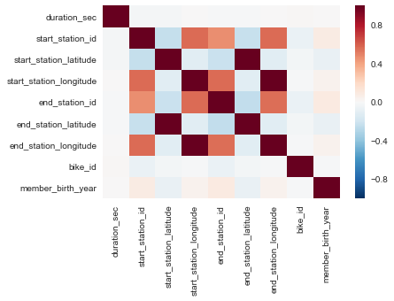

```python
sb.heatmap(df.corr())
plt.show()
```

We can see that there is a correlation between the Longitude , Latitude level which won't help us during our modelling. Let's look at these plots individually.

**Let's try to plot the Latitude and Longitude in the map , I am curious about it**

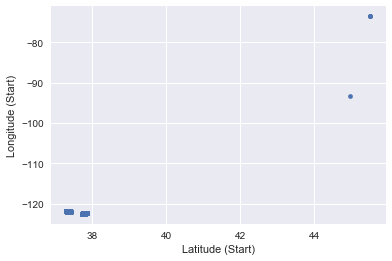

```python
df.plot(kind = 'scatter' , x= 'start_station_latitude' ,
        y= 'start_station_longitude').set(xlabel = 'Latitude (Start)' , ylabel = 'Longitude (Start)')
plt.show()
```

As we can see that the plots are on similar lines. For start and end.

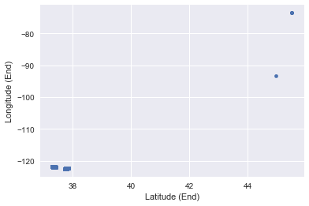

```python
df.plot(kind = 'scatter' , x= 'end_station_latitude' ,
        y= 'end_station_longitude').set(xlabel = 'Latitude (End)' , ylabel = 'Longitude (End)')
plt.show()
```

**Nothing concrete here , Hence we can ignore the latitude and longitude for further analysis** As previously mentioned , We are more focused on the user metrtics. **We want to know who should be our target customers ?** We are going to now see what has been the duration of travel for user types and genders

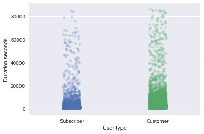

```python
g = sb.stripplot(x=df["user_type"] , y=df['duration_sec'] , jitter=True , alpha = 0.25)
g.set_xlabel('User type')
g.set_ylabel('Duration seconds')
plt.show()
```

**Looks like , Customers do tend to take a longer trip than the regular subscribers. It is pretty soon to establish whether the subscribers are regular and hence use for a smaller distance as compared to Customer who maybe recreational users hence the longer duration**

Furthermore , I want to switch the focus and check **Which gender takes more duration ?** **Why ? Because more duration means more revenue**

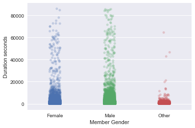

```python
g = sb.stripplot(x=df["member_gender"] , y=df['duration_sec'] , jitter=True ,alpha = 0.25)
g.set_xlabel('Member Gender')
g.set_ylabel('Duration seconds')
plt.show()
```

There's not much to make difference per say. Males and Females are renting the bikes for a similar duration.

Hence , We can explore **Which gender are our subscribers?**

```python
pd.crosstab(df["user_type"] , df['member_gender'])
```

| member_gender user_type | Female | Male | Other |
| --- | --- | --- | --- |
| Customer | 7279 | 15811 | 455 |
| Subscriber | 39991 | 115231 | 2491 |

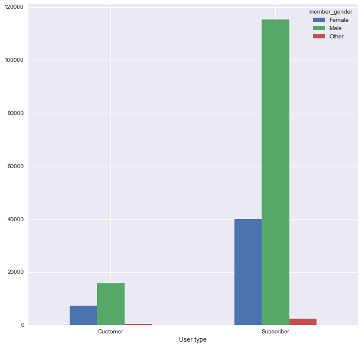

```python
pd.crosstab(df["user_type"] , df['member_gender']).plot(kind = 'bar' , figsize = (10,10) , rot = 0).set(xlabel = 'User type')
plt.show()
```

As we can see graphically above.

**One more interesting observation could be to check age of members as compared to the duration to see if there is a trend**

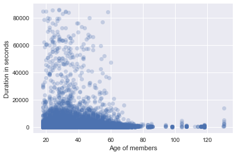

```python
g = sb.regplot(x='member_age',
            y='duration_sec',
            data=df,
            fit_reg=False,  # do not fit a regression line
            x_jitter=0.1,  # could also dynamically set this with range of data
            y_jitter=0.1,
            scatter_kws={'alpha': 0.25 })
g.set_xlabel('Age of members')
g.set_ylabel('Duration in seconds')
plt.show()
```

Scatter plot , Proves that people above the age of 25 and below 45 tend to take the trip for a longer duration.

**Which brings us to our next question , What's the age according to gender ? Do younger male take the Bike share more than Younger females ? Let's find out**

```python
pd.crosstab(df['member_age'] , df['member_gender'])
```

| member_gender member_age | Female | Male | Other |
| --- | --- | --- | --- |
| 18.0 | 145 | 385 | 8 |
| 19.0 | 433 | 1174 | 1 |
| 20.0 | 574 | 2121 | 22 |
| 21.0 | 814 | 2620 | 98 |
| 22.0 | 1160 | 2854 | 42 |
| 23.0 | 1511 | 4198 | 31 |
| 24.0 | 1843 | 4890 | 44 |
| 25.0 | 2236 | 5855 | 92 |
| 26.0 | 2278 | 5129 | 118 |
| 27.0 | 2777 | 5484 | 25 |
| 28.0 | 2917 | 5945 | 187 |
| 29.0 | 2580 | 5891 | 86 |
| 30.0 | 2818 | 8370 | 146 |
| 31.0 | 2521 | 6387 | 158 |
| 32.0 | 2228 | 5392 | 76 |
| 33.0 | 2189 | 5697 | 165 |
| 34.0 | 1752 | 5201 | 107 |
| 35.0 | 1683 | 4529 | 209 |
| 36.0 | 1428 | 4438 | 109 |
| 37.0 | 1184 | 3938 | 42 |
| 38.0 | 1070 | 3560 | 130 |
| 39.0 | 951 | 2599 | 98 |
| 40.0 | 646 | 2787 | 56 |
| 41.0 | 1340 | 2646 | 34 |
| 42.0 | 919 | 1806 | 156 |
| 43.0 | 616 | 2918 | 32 |
| 44.0 | 583 | 1938 | 52 |
| 45.0 | 336 | 1850 | 52 |
| 46.0 | 551 | 1864 | 43 |
| 47.0 | 573 | 1910 | 21 |
| ... | ... | ... | ... |
| 64.0 | 89 | 299 | 0 |
| 65.0 | 34 | 202 | 1 |
| 66.0 | 16 | 371 | 27 |
| 67.0 | 28 | 160 | 0 |
| 68.0 | 14 | 146 | 0 |
| 69.0 | 4 | 144 | 0 |
| 70.0 | 12 | 90 | 0 |
| 71.0 | 32 | 83 | 0 |
| 72.0 | 0 | 36 | 0 |
| 73.0 | 2 | 92 | 3 |
| 74.0 | 0 | 24 | 0 |
| 75.0 | 10 | 13 | 0 |
| 76.0 | 0 | 29 | 0 |
| 77.0 | 0 | 20 | 0 |
| 78.0 | 0 | 5 | 0 |
| 79.0 | 0 | 3 | 0 |
| 80.0 | 0 | 2 | 0 |
| 83.0 | 0 | 11 | 0 |
| 84.0 | 0 | 5 | 0 |
| 85.0 | 23 | 0 | 0 |
| 86.0 | 0 | 5 | 0 |
| 94.0 | 0 | 6 | 0 |
| 98.0 | 0 | 14 | 0 |
| 104.0 | 0 | 8 | 0 |
| 107.0 | 0 | 0 | 17 |
| 112.0 | 0 | 1 | 0 |
| 114.0 | 0 | 0 | 3 |
| 116.0 | 15 | 0 | 0 |
| 118.0 | 4 | 45 | 4 |
| 130.0 | 0 | 0 | 10 |

76 rows × 3 columns

Let's take a look for users above the birth year of 1970s in terms of gender.

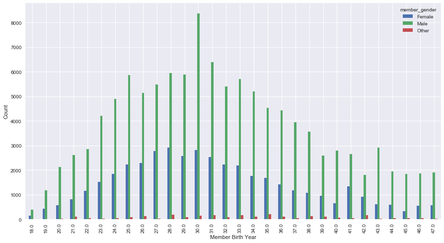

```python
pd.crosstab(df.query('member_birth_year > 1970')['member_age'] ,
            df.query('member_birth_year > 1970')['member_gender']).plot(kind = 'bar' , figsize = (15 ,8))
plt.xlabel('Member Birth Year')
plt.ylabel('Count')
plt.show()
```

Both the gender show similar trends when it comes to age wise comparison. Females of the age 28 take the highest amount of rides whilst Males of the age 30 seem to care more about their fitness.

**Let's take a look at the user type through the age. Do young users subscribe to our services as compared to the old users?**

```python
pd.crosstab(df['member_age'] , df['user_type'])
```

| user_type member_age | Customer | Subscriber |
| --- | --- | --- |
| 18.0 | 290 | 248 |
| 19.0 | 536 | 1072 |
| 20.0 | 464 | 2253 |
| 21.0 | 633 | 2899 |
| 22.0 | 912 | 3144 |
| 23.0 | 797 | 4943 |
| 24.0 | 849 | 5928 |
| 25.0 | 1041 | 7142 |
| 26.0 | 1234 | 6291 |
| 27.0 | 1114 | 7172 |
| 28.0 | 1191 | 7858 |
| 29.0 | 1263 | 7294 |
| 30.0 | 1770 | 9564 |
| 31.0 | 1097 | 7969 |
| 32.0 | 975 | 6721 |
| 33.0 | 968 | 7083 |
| 34.0 | 829 | 6231 |
| 35.0 | 883 | 5538 |
| 36.0 | 564 | 5411 |
| 37.0 | 618 | 4546 |
| 38.0 | 546 | 4214 |
| 39.0 | 434 | 3214 |
| 40.0 | 390 | 3099 |
| 41.0 | 363 | 3657 |
| 42.0 | 253 | 2628 |
| 43.0 | 287 | 3279 |
| 44.0 | 327 | 2246 |
| 45.0 | 271 | 1967 |
| 46.0 | 262 | 2196 |
| 47.0 | 254 | 2250 |
| ... | ... | ... |
| 64.0 | 42 | 346 |
| 65.0 | 18 | 219 |
| 66.0 | 41 | 373 |
| 67.0 | 10 | 178 |
| 68.0 | 13 | 147 |
| 69.0 | 5 | 143 |
| 70.0 | 4 | 98 |
| 71.0 | 3 | 112 |
| 72.0 | 3 | 33 |
| 73.0 | 2 | 95 |
| 74.0 | 4 | 20 |
| 75.0 | 0 | 23 |
| 76.0 | 0 | 29 |
| 77.0 | 0 | 20 |
| 78.0 | 0 | 5 |
| 79.0 | 2 | 1 |
| 80.0 | 0 | 2 |
| 83.0 | 0 | 11 |
| 84.0 | 0 | 5 |
| 85.0 | 0 | 23 |
| 86.0 | 0 | 5 |
| 94.0 | 6 | 0 |
| 98.0 | 0 | 14 |
| 104.0 | 0 | 8 |
| 107.0 | 0 | 17 |
| 112.0 | 1 | 0 |
| 114.0 | 3 | 0 |
| 116.0 | 0 | 15 |
| 118.0 | 8 | 45 |
| 130.0 | 0 | 10 |

76 rows × 2 columns

Here's a representation for people born after 1970s for individual user types

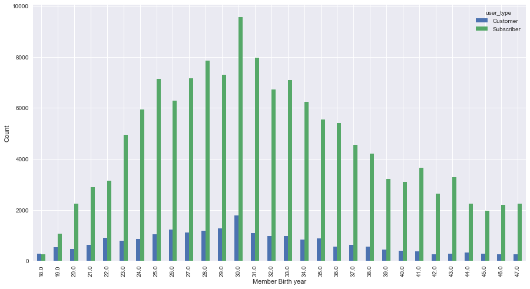

```python
pd.crosstab(df.query('member_birth_year > 1970')['member_age'] ,
            df.query('member_birth_year > 1970')['user_type']).plot(kind = 'bar' , figsize = (15 ,8))
plt.xlabel('Member Birth year')
plt.ylabel('Count')
plt.show()
```

We can see that 30 year old have the highest for Customers as well as Subscribers.

Since we are looking more about the users , We may also want to know **who share their rides the most ?**

```python
pd.crosstab(df['bike_share_for_all_trip'] , df['member_gender'])
```

| member_gender bike_share_for_all_trip | Female | Male | Other |
| --- | --- | --- | --- |
| No | 43246 | 119990 | 2638 |
| Yes | 4024 | 11052 | 308 |

Seems like the trend is similar for Male and Female.

**We can also see bike share vs user type. We do know that Bike share is only available for Subscribers** We can confirm this below

```python
pd.crosstab(df['bike_share_for_all_trip'] , df['user_type'])
```

| user_type bike_share_for_all_trip | Customer | Subscriber |
| --- | --- | --- |
| No | 30705 | 146042 |
| Yes | 0 | 15384 |

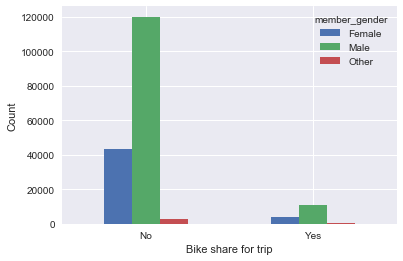

```python
pd.crosstab(df['bike_share_for_all_trip'] , df['member_gender']).plot(kind = 'bar' , rot = 0)
plt.xlabel('Bike share for trip')
plt.ylabel('Count')
plt.show()
```

**Bike sharers are pretty low , There is no conclusive difference out here!**

### Talk about some of the relationships you observed in this part of the investigation. How did the feature(s) of interest vary with other features in the dataset?

> My main interest was to check for user demographics. This would help us identify our target customers. Features such as user type , gender and birth year was our primary interest. We did observe a striking difference in terms of subscribers. But we would take it to another level at the Multivariate section

### Did you observe any interesting relationships between the other features (not the main feature(s) of interest)?

> 1988 seems to be a very interesting year in terms of subscribers. Most of our subscriber are pretty much in their 30s.I believed that Longitude and Latitude may differ but after plotting it was similar hence I felt that I mustn't focus on it.

## Multivariate Exploration

In this section , We would focus more on the aspect of User demographic. Check some psychological or habitual conditions.

**This part is crucial as it would enable us to find more about the user habits and can help us in advertising or looking out for target customers**

First thing , We want to find is **Based on the members gender and user type which particular type of users take more ride.**

We are going ahead with the boxplot in this section , Since we want to find the averaging cause. We have a population data where the male riders are more in amount and it would be pretty unfair to only target Male customers on that note

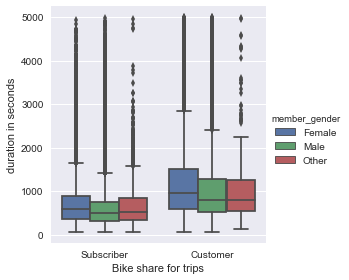

```python
g = sb.factorplot(x="user_type", y="duration_sec", hue="member_gender", kind="box",
                  data=df.query('duration_sec < 5000'))
g.set_xlabels('Bike share for trips')
g.set_ylabels('duration in seconds')
plt.show()
```

As we can see here , Female customers tend to travel more in duration than Male Customers in terms of the Boxplot. Infact , This trend can also be noticed in the Subscriber too. Another pretty important thing we can observe is Female customers tend to take more duration than Female subscribers

**One of the interesting plot could be to see behavorial aspect in terms of the day of the week. We would be able to check a certain trend**

**We now want to see whether the day has any impact from the above ?**

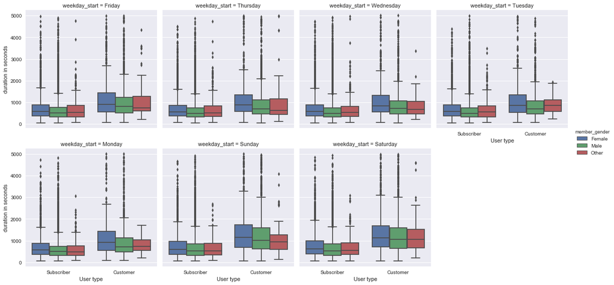

```python
g = sb.factorplot(x="user_type", y="duration_sec",col = 'weekday_start',hue="member_gender",col_wrap=4, kind="box",
                  data=df.query('duration_sec < 5000'))
g.set_xlabels('User type')
g.set_ylabels('duration in seconds')
plt.show()
```

**In terms of the above figure** , We can see that Male customers as well as Female customers tend to have a longer duration on Saturday and Sunday.

This particular trend can be super useful. We can expect higher duration of rides on Saturday and Sunday even though the numbers on the particular days are low.

Looks like the trend is similar in terms of user types for Male and Female.

**Who shares the ride ? and on what day?**

This again can be pretty useful for us to cope up with the expectation level of the customer and advertising. Maybe in terms of a scheme that on a particular day you get some 10% discount in order to hike up the numbers. Also , The gender type can give a bit of a targeting mechanism.

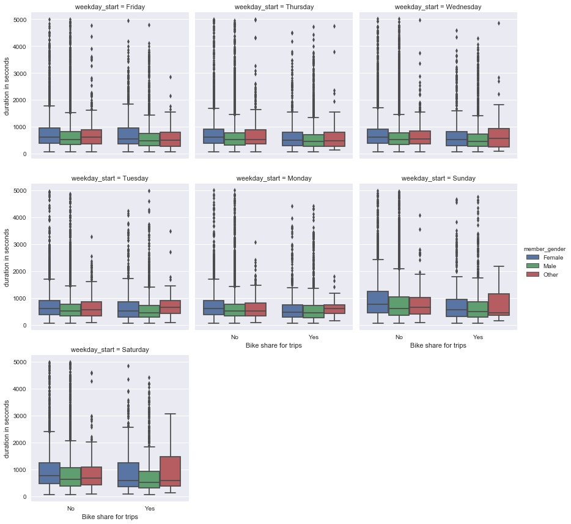

```python
g = sb.factorplot(y="duration_sec",col = 'weekday_start',col_wrap= 3 ,x = 'bike_share_for_all_trip' ,hue="member_gender", kind="box",
                  data=df.query('duration_sec < 5000'))
g.set_xlabels('Bike share for trips')
g.set_ylabels('duration in seconds')
plt.show()
```

Ride share duration increases on Saturday and Sunday , a well known fact from the above analysis. We can also see that Female ride sharers tend to spend more duration on the weekends similar to other gender and Males. We can even take a look at the duration in seconds in terms of age

**In terms of the user types and Gender , We may want to see the distribution of data when we compare to the age to get a good sense of idea**

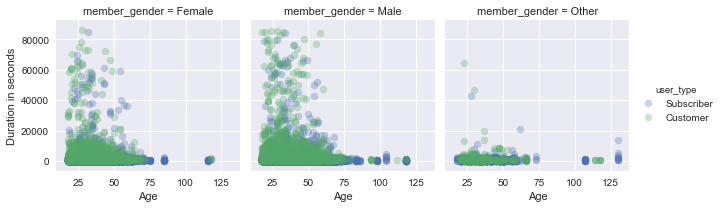

```python
g = sb.FacetGrid(data=df ,col = 'member_gender' , hue = 'user_type')
g.map(plt.scatter , 'member_age','duration_sec' , alpha = 0.3).add_legend()
g.set_xlabels('Age')
g.set_ylabels('Duration in seconds')
g.set_xticklabels()
plt.show()
```

As we can see that Male and Female riders whether they are subscriber or customer tend to have a similar duration in terms of age.

### Talk about some of the relationships you observed in this part of the investigation. Were there features that strengthened each other in terms of looking at your feature(s) of interest?

> I felt that year of birth was super interesting in terms of advertising and marketing. We can particularly target people of age around 30 since they tend to spend more time which in turn leads to more profitablity. We also noticed that Female customers spend more time on Weekday as compared to men.

### Were there any interesting or surprising interactions between features?

> The interaction between weekday , gender and user type had a surprising interaction. We came to know women spend more time as a customer as compared to subscribers